# Reproducible Research: Peer Assessment 1

It is now possible to collect a large amount of data about personal movement using activity monitoring devices such as a Fitbit, Nike Fuelband, or Jawbone Up. These type of devices are part of the “quantified self” movement – a group of enthusiasts who take measurements about themselves regularly to improve their health, to find patterns in their behavior, or because they are tech geeks. But these data remain under-utilized both because the raw data are hard to obtain and there is a lack of statistical methods and software for processing and interpreting the data.

This assignment makes use of data from a personal activity monitoring device. This device collects data at 5 minute intervals through out the day. The data consists of two months of data from an anonymous individual collected during the months of October and November, 2012 and include the number of steps taken in 5 minute intervals each day.

## Loading and preprocessing the data

Unzip data file in working directory and load CSV file into memory. Removes CSV file once loaded into memory.

```r
zipFile <- "activity.zip"
unzip(zipFile)
dataFile <- "activity.csv"
data.all <- read.csv(dataFile)
unlink(dataFile)
```

Convert date column into date data type.

```r
data.all$date <- as.Date(data.all$date , format = "%Y-%m-%d")
```

## What is mean total number of steps taken per day?

### Total number of steps taken each day

```r
library('plyr')
## Create summary table with total number of steps each day
summary.stepsDay <- ddply(data.all, .(date), summarize, totalSteps = sum(steps, na.rm = TRUE))
```

```
## stat_bin: binwidth defaulted to range/30. Use 'binwidth = x' to adjust this.
```

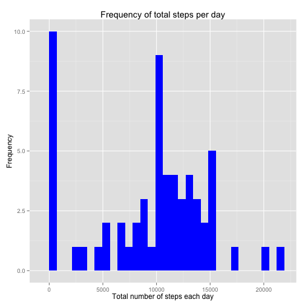

```r
library('ggplot2')
## Plot summary data
figure.stepsDay <- ggplot(summary.stepsDay, aes(x = totalSteps)) +
                   geom_histogram(fill="blue") +
                   ggtitle("Frequency of total steps per day") +
                   xlab("Total number of steps each day") +
                   ylab("Frequency")

plot(figure.stepsDay)
```

### The mean and median total number of steps taken per day

```r
meanStepsDay <- mean(summary.stepsDay$totalSteps, na.rm = TRUE)
```

*Mean* number of steps per day: **9354.2295**

```r
medianStepsDay <- median(summary.stepsDay$totalSteps, na.rm = TRUE)
```

*Median* number of steps per day: **10395**

## What is the average daily activity pattern?

### Time series plot of the average number of steps taken at each interval

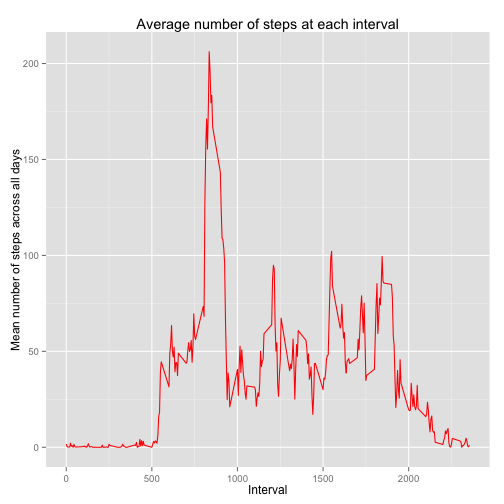

```r
library(ggplot2)
library(plyr)
summary.stepsInterval <- ddply(data.all, .(interval), summarize,
                               meanSteps = mean(steps, na.rm = TRUE))

figure.stepsInterval <- ggplot(summary.stepsInterval,
                               aes(x = interval, y = meanSteps)) +
                        geom_line(color = "red") +
                        ggtitle("Average number of steps at each interval") +
                        xlab("Interval") +
                        ylab("Mean number of steps across all days")

plot(figure.stepsInterval)
```

### The five minute interval that on average contains the most number of steps

```r
summary.stepsIntervalMax <- summary.stepsInterval[which.max(summary.stepsInterval$meanSteps),]
intervalMax <- summary.stepsIntervalMax$interval
```

Five minute interval that on average contains the most number of steps is: **835**